# InVivoStat Summary Statistics

## Variable selection

Responses Resp 2,Resp8,Resp9 are analysed in this module, with results categorised by factor Cat4. The responses have been square root transformed prior to analysis.

## Categorised summary statistics

### Summary statistics for Resp 2 categorised by Cat4

| Categorisation Factor levels | Mean | N | Variance | Std dev | Std error | %CV | Lower 99% CI | Upper 99% CI | Min | Max | Median | Lower quartile | Upper quartile |
| --- | --- | --- | --- | --- | --- | --- | --- | --- | --- | --- | --- | --- | --- |
| A | 0.5380 | 8 | 0.1192 | 0.3453 | 0.1221 | 64.2 | 0.1108 | 0.9652 | 0.0655 | 0.9692 | 0.6092 | 0.2104 | 0.8150 |
| B | 0.6392 | 8 | 0.0965 | 0.3106 | 0.1098 | 48.6 | 0.2549 | 1.0235 | 0.2582 | 0.9790 | 0.5866 | 0.3826 | 0.9691 |
| C | 0.6944 | 8 | 0.0581 | 0.2409 | 0.0852 | 34.7 | 0.3963 | 0.9925 | 0.3590 | 0.9911 | 0.7286 | 0.4876 | 0.8862 |
| D | 0.6525 | 8 | 0.0541 | 0.2326 | 0.0822 | 35.6 | 0.3647 | 0.9402 | 0.3390 | 0.9269 | 0.6634 | 0.4399 | 0.8736 |

### Summary statistics for Resp8 categorised by Cat4

| Categorisation Factor levels | Mean | N | Variance | Std dev | Std error | %CV | Lower 99% CI | Upper 99% CI | Min | Max | Median | Lower quartile | Upper quartile |
| --- | --- | --- | --- | --- | --- | --- | --- | --- | --- | --- | --- | --- | --- |
| A | 0.6281 | 8 | 0.0803 | 0.2833 | 0.1002 | 45.1 | 0.2775 | 0.9786 | 0.1877 | 0.9934 | 0.5359 | 0.4731 | 0.9127 |
| B | 0.5613 | 8 | 0.0846 | 0.2909 | 0.1029 | 51.8 | 0.2014 | 0.9213 | 0.1626 | 0.9299 | 0.6044 | 0.2809 | 0.8138 |
| C | 0.6089 | 8 | 0.0788 | 0.2807 | 0.0993 | 46.1 | 0.2616 | 0.9563 | 0.1774 | 0.8473 | 0.6963 | 0.3827 | 0.8445 |
| D | 0.6353 | 8 | 0.0333 | 0.1826 | 0.0646 | 28.7 | 0.4094 | 0.8612 | 0.3756 | 0.9656 | 0.6637 | 0.4950 | 0.7121 |

### Summary statistics for Resp9 categorised by Cat4

| Categorisation Factor levels | Mean | N | Variance | Std dev | Std error | %CV | Lower 99% CI | Upper 99% CI | Min | Max | Median | Lower quartile | Upper quartile |
| --- | --- | --- | --- | --- | --- | --- | --- | --- | --- | --- | --- | --- | --- |
| A | 0.6634 | 8 | 0.0486 | 0.2205 | 0.0780 | 33.2 | 0.3906 | 0.9361 | 0.2525 | 0.9228 | 0.6733 | 0.5518 | 0.8408 |
| B | 0.6812 | 8 | 0.0411 | 0.2028 | 0.0717 | 29.8 | 0.4302 | 0.9321 | 0.3935 | 0.9069 | 0.7118 | 0.4982 | 0.8645 |
| C | 0.7204 | 8 | 0.0761 | 0.2759 | 0.0976 | 38.3 | 0.3790 | 1.0618 | 0.2395 | 0.9944 | 0.7873 | 0.5074 | 0.9700 |
| D | 0.8115 | 8 | 0.0477 | 0.2183 | 0.0772 | 26.9 | 0.5414 | 1.0816 | 0.3307 | 0.9946 | 0.8594 | 0.7507 | 0.9733 |

## Normal probability plots

### Categorised Normal probability plot for Resp 2

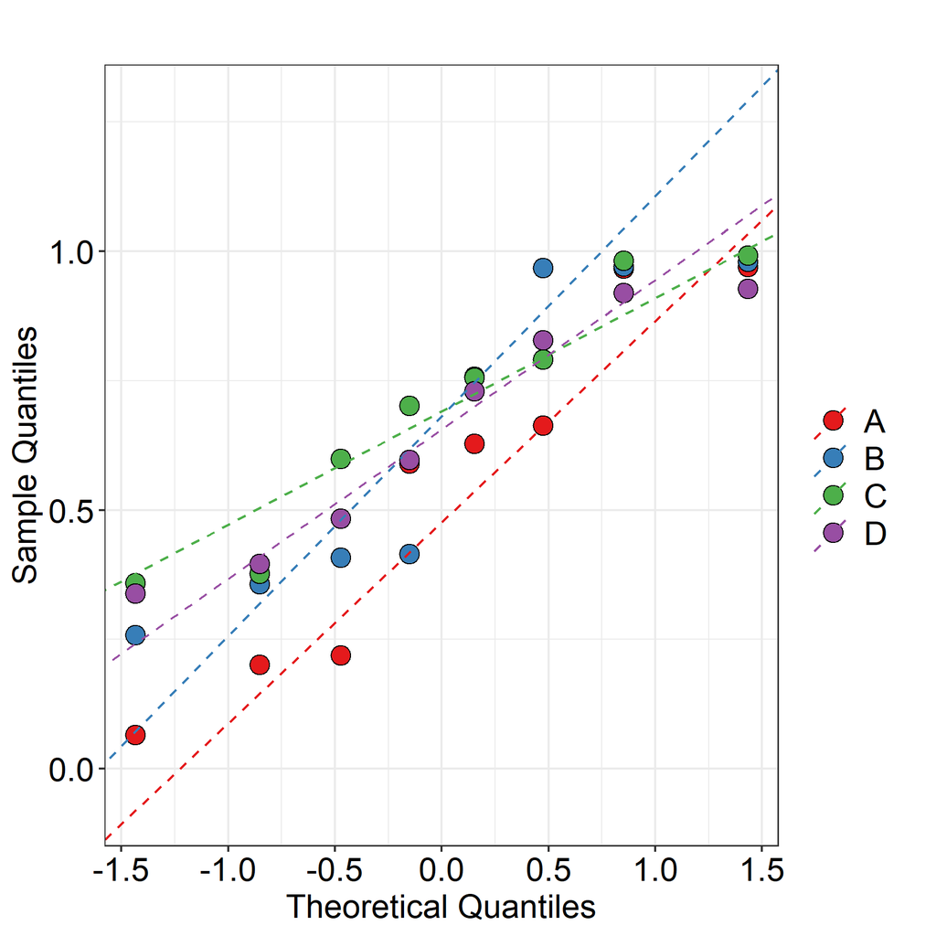

### Categorised Normal probability plot for Resp8

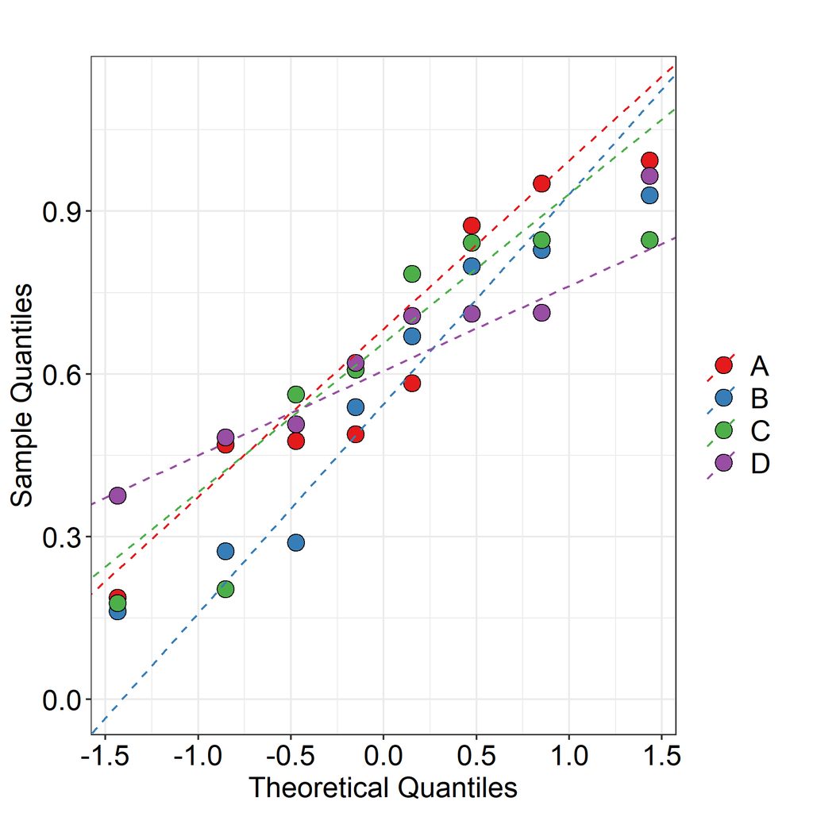

### Categorised Normal probability plot for Resp9

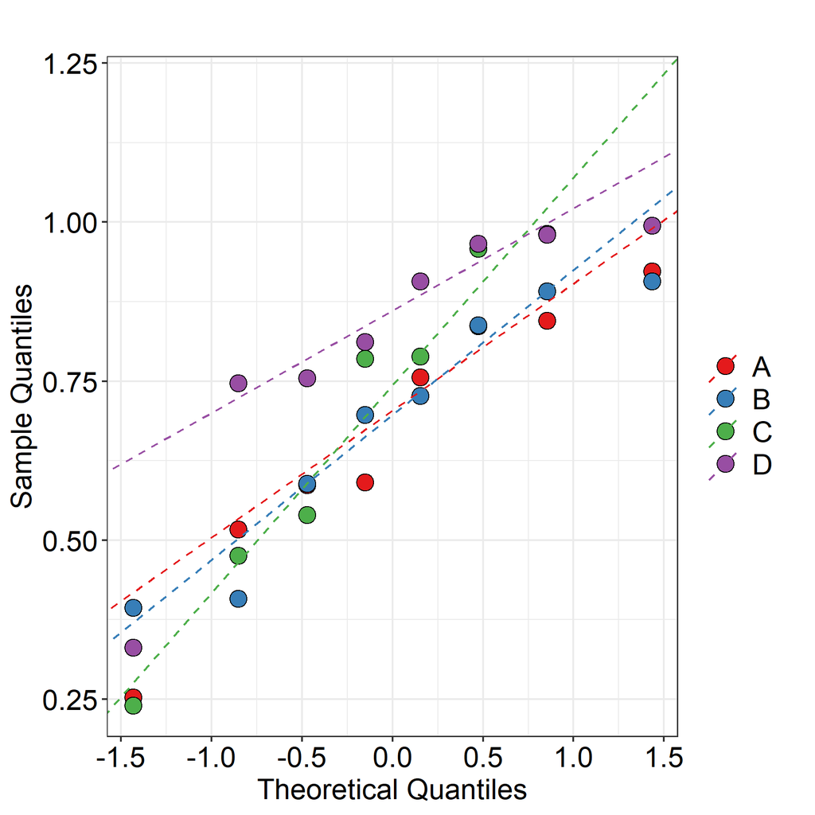

Tip: Check that the points lie along the dotted lines. If not then the data may be non-normally distributed.

## Non-categorised summary statistics

### Overall summary statistics for Resp 2, ignoring the categorisation factor

| Response | Mean | N | Variance | Std dev | Std error | %CV | Lower 99% CI | Upper 99% CI | Min | Max | Median | Lower quartile | Upper quartile |
| --- | --- | --- | --- | --- | --- | --- | --- | --- | --- | --- | --- | --- | --- |
| Resp 2 | 0.6310 | 32 | 0.0774 | 0.2783 | 0.0492 | 44.1 | 0.4960 | 0.7660 | 0.0655 | 0.9911 | 0.6459 | 0.3865 | 0.9229 |

### Overall summary statistics for Resp8, ignoring the categorisation factor

| Response | Mean | N | Variance | Std dev | Std error | %CV | Lower 99% CI | Upper 99% CI | Min | Max | Median | Lower quartile | Upper quartile |
| --- | --- | --- | --- | --- | --- | --- | --- | --- | --- | --- | --- | --- | --- |
| Resp8 | 0.6084 | 32 | 0.0634 | 0.2518 | 0.0445 | 41.4 | 0.4862 | 0.7306 | 0.1626 | 0.9934 | 0.6138 | 0.4731 | 0.8354 |

### Overall summary statistics for Resp9, ignoring the categorisation factor

| Response | Mean | N | Variance | Std dev | Std error | %CV | Lower 99% CI | Upper 99% CI | Min | Max | Median | Lower quartile | Upper quartile |
| --- | --- | --- | --- | --- | --- | --- | --- | --- | --- | --- | --- | --- | --- |
| Resp9 | 0.7191 | 32 | 0.0516 | 0.2272 | 0.0402 | 31.6 | 0.6089 | 0.8293 | 0.2395 | 0.9946 | 0.7707 | 0.5629 | 0.9069 |

## Normal probability plots

### Normal probability plot for Resp 2, ignoring the categorisation factor

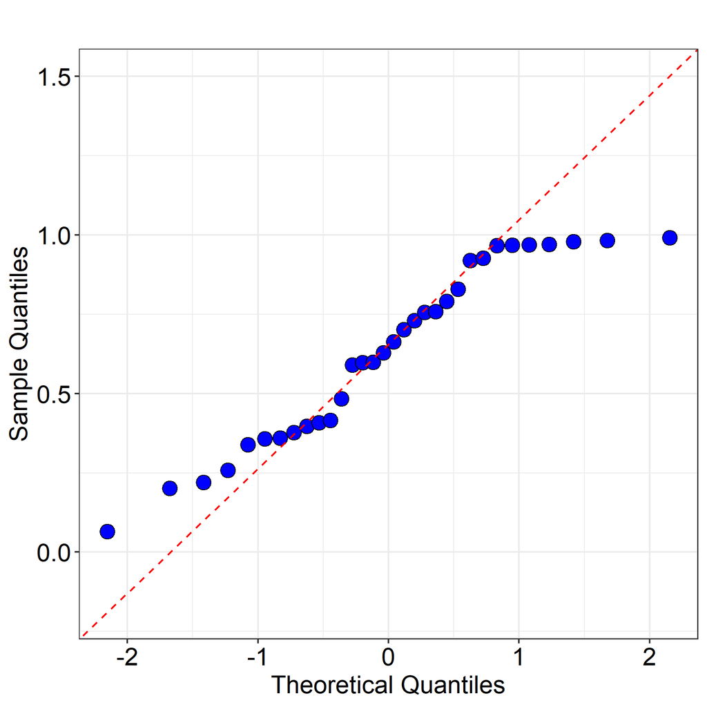

### Normal probability plot for Resp8, ignoring the categorisation factor

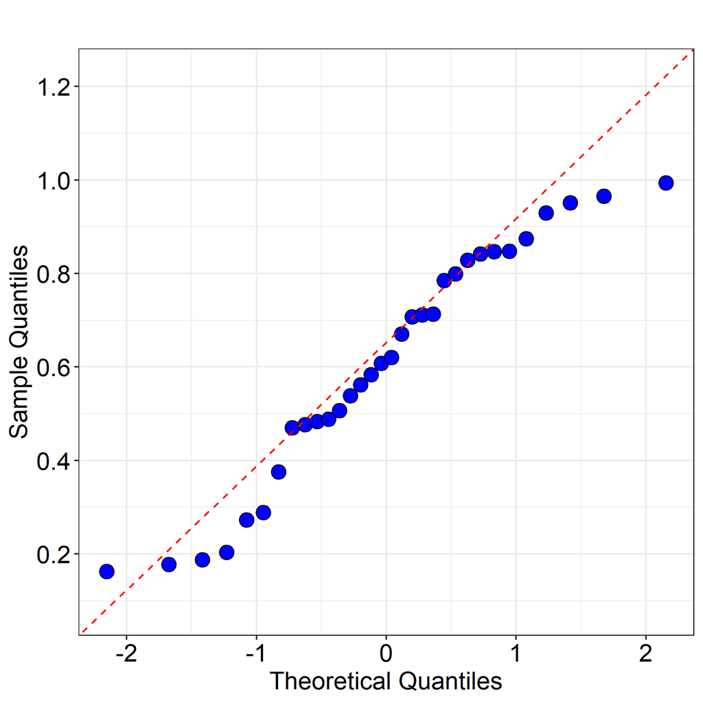

### Normal probability plot for Resp9, ignoring the categorisation factor

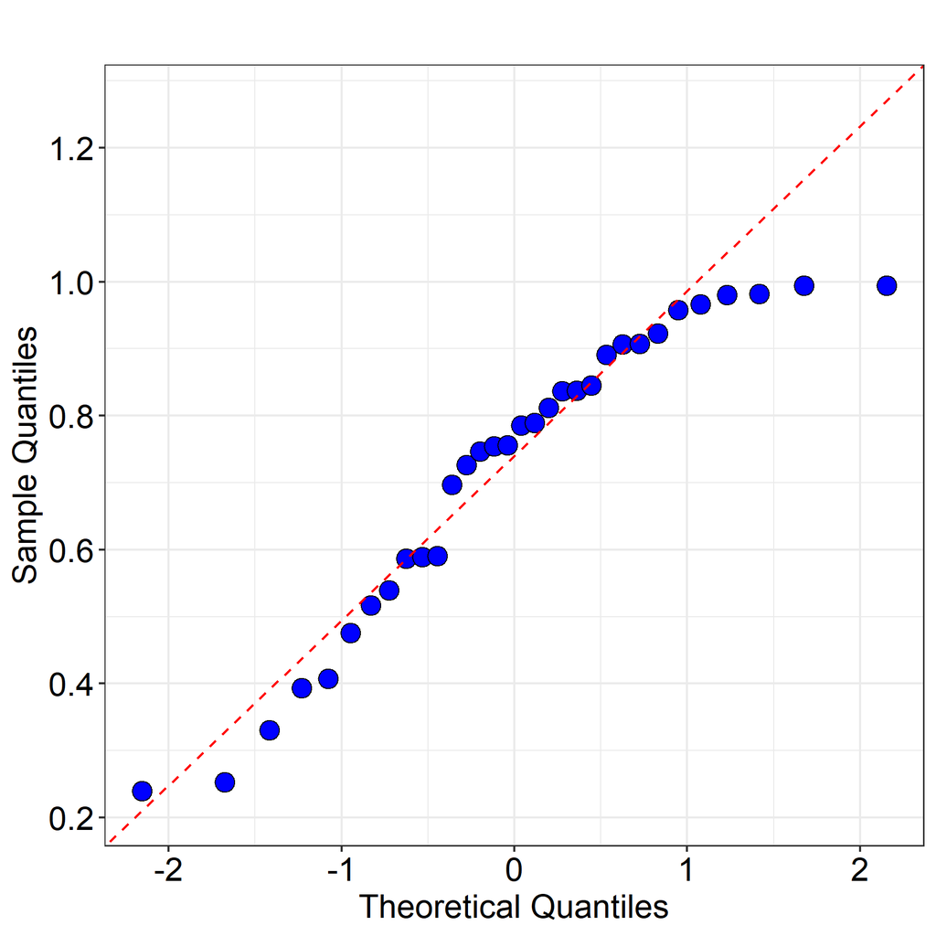

Tip: Check that the points lie along the dotted line. If not then the data may be non-normally distributed.

Warning: Note the normal probability plots presented in the Summary Statistics module do not take into account any design factors. Hence the response(s) may appear to be non-normally distributed due to the effect of any design factors. If you have factors that may influence the response(s), then it is recommended that you use the normal probability plot in the Single or Repeated Measures Parametric Analysis module, which does take these factors into account.

For more information on the theoretical approaches that are implemented within this module, see Bate and Clark (2014).

## References

When referring to InVivoStat, please cite 'InVivoStat, version 5.2.0'.

Bate, S.T. and Clark, R.A. (2014). The Design and Statistical Analysis of Animal Experiments. Cambridge University Press.